# inference-report

Nutcha Kiraniphonphan

2023-08-06

## Introduction

The purpose of this empirical project is to investigate the real wage gap in dollars of two groups of population, non-immigrants and immigrants. In addition to the real wage gap, other factors that could explain the differences between them are also investigated. The regression function is utilized for the goals, in addition to economic theory and research. After the explanation is established, the next purpose is to find out whether the wage gaps change since the immigrants have moved to the US.

## Data

The data used for this empirical project is “Current Population Survey (CPS)” from 2019 by “Center for Economic and Policy Research”. Since the purpose of this project is to investigate the real wage gap, the dependent variable is *rw* (real wage) and *forborn* (whether the individual is foreign born) is the base independent variable. However, it seems that the *forborn* factor alone cannot explain the real wage gap. There are other factors that also needs be investigated, e.g., marital status and education, to yield a more complete explanation.

The data excludes person with missing values for *rw*, which are either not in the work force or unemployed, therefore, the data is left with 154279 persons. The data of the real wage is given as *rw*, however, it is transformed into *log(rw)*. The reasons are that it is the customary according to economic research, and also it gives a variable distribution that is more amenable to analysis. The base independent variable is whether they are immigrants, for which *forborn* seems to be the best suited variable for this purpose.  
For the other explanation related to the immigrant groups, the independent variable is *prinusyr*. The *prinusyr* is used and not the *arrived* variable, because it has more recent data and also has a nicer distribution. The alternative independent variables are chosen based on economic theory and research. The factors that will be investigated in the model are related to human capital and demographics. These other factors are age, education, sex, marital status, and race.  
I have chosen not to exclude the outliers, even though OLS is sensitive to outliers. Since the size of the samples are large, it is assumed to have the sampling distribution. I also ignore that some individuals have multiple jobs. The 95% confidence interval is the critical value throughout the report.

## Empirical Approach

The main method of finding the potential independent variables is utilizing the economic knowledge and available resources from books or research papers to outline which factors will most likely affect the real wage gap.

### Regression function for the wage gap (task a)

> $$log(y_i) = \beta_0 + \beta_{fb} \cdot
> fb_i + \beta_{fe} \cdot fe_i + \beta_{age1} \cdot age_i + \beta_{age2}
> \cdot {age_i}^2 + \beta_{educ} \cdot educ_i + \beta_{marstat} \cdot
> marstat_i + \beta_{wbho} \cdot wbho_i + u_i$$

$\beta_{fb}$ is the variable indicates whether the individual is an immigrant.  
$\beta_{fe}$ is a variable indicates whether the individual is a female.  
Age is represented two variables:  
$\beta_{age1}$ is a variable that models increasing return as a function of age.  
$\beta_{age2}$ is the counter part of $\beta_{age1}$, modelling diminishing return with old age.  
$\beta_{educ}$ is a variable that indicates the level of education.  
$\beta_{marstat}$ is a variable that indicates the marital status.  
$\beta_{wbho}$ is a variable that indicates race of the individual.  
$u_i$ is the error term capturing the regression residual due to omitted independent variables.

The hypotheses are that the coefficient of *forborn* should be negative and be in the same direction of the mean real wage in the next section. Female should have lower wage than male, so the coefficient is suspected to be negative. Age is suspected to be increasing in the beginning and decreasing at the end, therefore $\beta_{age1}$ should be positive and $\beta_{age2}$ should be negative. The coefficient of the level of education should be positive and increasing in magnitude as the level of education raises. For individuals who are not married, the coefficient is suspected to be negative. The coefficients for other races should be lower than the dummy variable, *wbhoWhite*.

### Regression function for analysis wage gap with time (task b)

> $$log(y_i) = \beta_0 + \beta_{fb} \cdot
> fb_i + \beta_{fe} \cdot fe_i + \beta_{age1} \cdot age_i + \beta_{age2}
> \cdot {age_i}^2 + \beta_{educ} \cdot educ_i + \beta_{marstat} \cdot
> marstat_i + \beta_{prinusyr} \cdot prinusyr_i + \beta_{wbho} \cdot
> wbho_i + u_i$$

$\beta_{fb}$ is the variable indicates whether the individual is an immigrant.  
$\beta_{fe}$ is a variable indicates whether the individual is a female.  
Age is represented two variables:  
$\beta_{age1}$ is a variable that models increasing return as a function of age.  
$\beta_{age2}$ is the counter part of $\beta_{age1}$, modelling diminishing return with old age.  
$\beta_{educ}$ is a variable that indicates the level of education.  
$\beta_{marstat}$ is a variable that indicates the marital status.  
$\beta_{wbho}$ is a variable that indicates race of the individual.  
$\beta_{prinusyr}$ is a variable indicates years since the immigrants have entered the US.  
$u_i$ is the error term.

The model is similar to the one above, however the variable *prinusyr* is added, so we can probably have a better picture. The hypothesis is that the wage gap should be smaller as the variable year increases. This could be the caused by effects such as language barriers and integration. However, the *prinusyr* variable is a categorical variable indicating the range of year the individual moved to the US, i.e. a value of 1 corresponds to moving before 1950 while the higher the value the more recent the individual moved to the US, in addition to *prinusyr* for the natives, which will be added.

## Results

The mean real wage gap before data transformation is $25.95 - $25.32 = $0.63, which means 2.49% reduction for immigrants. The statistical values regarding the real wage are listed in table 1. The distribution is also shown in figure 1 and 2.

Table 1: Real wage of non-immigrants and immigrants

| Name | Mean | SD | Min | Max | Median | Quantile.05 | Quantile.95 | N |
| --- | --- | --- | --- | --- | --- | --- | --- | --- |
| Non-immigrants - rw | 25.95 | 19.60 | 1 | 392.30 | 20.00 | 9.0 | 64.60 | 132180 |
| Immigrants - rw | 25.32 | 20.56 | 1 | 288.33 | 18.00 | 9.0 | 68.83 | 22099 |
| Non-immigrants -log(rw) | 3.05 | 0.63 | 0 | 5.97 | 3.00 | 2.2 | 4.17 | 132180 |
| Immigrants - log(rw) | 3.00 | 0.65 | 0 | 5.66 | 2.89 | 2.2 | 4.23 | 22099 |

### Hypothesis testing of the real mean

#### Two-sided t-test

Null hypothesis:

$H_0: \mu_{im} = \mu_{non}$

Alternative hypothesis:

$H_1: \mu_{im} \neq \mu_{non}$

```
##
##  Two Sample t-test
##
## data:  dt$rw[dt$forborn == 1] and dt$rw[dt$forborn == 0]
## t = -4.4178, df = 154277, p-value = 9.977e-06
## alternative hypothesis: true difference in means is not equal to 0
## 95 percent confidence interval:
##  -0.9149068 -0.3525823
## sample estimates:
## mean of x mean of y
##  25.31543  25.94918
```

From the t-test, we can reject the null hypothesis that the true mean of immigrants and non-immigrants are equal with 95% confidence interval.

### The regression analysis of immigrants and non-immigrants

#### Regression function for the wage gap (task a)

> $$y_i = \beta_0 + \beta_{fo} \cdot fo_i +
> \beta_{age1} \cdot age_i + \beta_{age2} \cdot {age_i}^2 + \beta_{fe}
> \cdot fe_i + \beta_{educ} \cdot educ_i + \beta_{marstat} \cdot
> marstat_i + \beta_{wbho} \cdot wbho_i + u_i$$

```
##
## Call:
## lm(formula = log(rw) ~ forborn + age + I(age^2) + female + educ +
##     marstat + wbho, data = dt)
##
## Residuals:
##     Min      1Q  Median      3Q     Max
## -3.7393 -0.2985 -0.0088  0.2983  2.9723
##
## Coefficients:
##                        Estimate Std. Error t value Pr(>|t|)
## (Intercept)           1.755e+00  1.357e-02 129.307  < 2e-16 ***
## forborn1             -5.437e-02  4.435e-03 -12.257  < 2e-16 ***
## age                   4.643e-02  5.806e-04  79.963  < 2e-16 ***
## I(age^2)             -4.566e-04  6.286e-06 -72.630  < 2e-16 ***
## female1              -2.252e-01  2.639e-03 -85.327  < 2e-16 ***
## educHS                1.785e-01  5.889e-03  30.317  < 2e-16 ***
## educSome college      2.899e-01  5.944e-03  48.775  < 2e-16 ***
## educCollege           6.612e-01  6.090e-03 108.577  < 2e-16 ***
## educAdvanced          8.778e-01  6.528e-03 134.472  < 2e-16 ***
## marstatWidowed       -6.391e-02  9.565e-03  -6.681 2.38e-11 ***
## marstatDivorced      -5.914e-02  4.433e-03 -13.340  < 2e-16 ***
## marstatSeparated     -8.588e-02  9.847e-03  -8.721  < 2e-16 ***
## marstatNever Married -9.660e-02  3.596e-03 -26.860  < 2e-16 ***
## wbhoBlack            -1.260e-01  4.489e-03 -28.064  < 2e-16 ***
## wbhoHispanic         -5.312e-02  4.305e-03 -12.339  < 2e-16 ***
## wbhoOther             2.422e-02  5.323e-03   4.550 5.36e-06 ***
## ---
## Signif. codes:  0 '***' 0.001 '**' 0.01 '*' 0.05 '.' 0.1 ' ' 1
##
## Residual standard error: 0.5119 on 154263 degrees of freedom
##   (137111 observations deleted due to missingness)
## Multiple R-squared:  0.3376, Adjusted R-squared:  0.3376
## F-statistic:  5243 on 15 and 154263 DF,  p-value: < 2.2e-16
```

The first regression is to determine which factors contribute to the wage gap differences in the population between immigrants and non-immigrants. The possible factors are included in the regression model, and the results are interpreted whether they are according to the hypotheses. Some possible factors are left out due to limitation of my knowledge and not to overcrowd the model, however, they would be mentioned if they could possibly contribute to the difference in the real wage. The result shows that 33.76% of the real wage variation can be accounted for by the six mentioned factors (including *forborn*) with F=5243 and p<0.001. All the coefficients are statistically significant at 95% confidence interval, with p<0.001. The coefficients seem to be in the correct directions according to the mentioned economic theories. The correlation plots are in the appendices.

##### *age*

Since age was assumed to positively correlate with real wage if age is low, the result of aging from 25 to 26 is a raise in real wage by approximately 2.32%, while the result of aging from 62 to 63 is a reduction in real wage by approximately 1.06%. The t-statistic and p-value indicate that *age* and *I(age^2)* are statistically significant.

##### *female*

Being a female results to a reduction in the real wage by approximately 20.164%. The direction seems to be the same as expected. Supported by the data from “Office of Federal Contract Compliance Programs (OFCCP)” and economic research that gender does have causal effect on the real wage. The t-statistic and p-value mean that it is statistically significant.

##### *educ*

The *educ* variable is a factor with the values of *educLTHS* (lower than high school), *educHS* (high school), *educSome College* (Some college), *educCollege* (College), and *educAdvanced* (Advanced).

*educLTHS* (lower than high school): This group is the dummy, so there is no effect from educ. *educHS* (high school): Finishing high school results to an increasing in real wage by approximately 19.54%. _educSome College (some college): Having some college increases the real wage by approximately 33.63%. *educCollege* (college): Having college degree results to an increasing in real wage by 93.71%. *educAdvanced* (advanced): Having higher education than college degree increases the real wage by 140.56%.

As suspected, the level of education has an impact on the real wage, i.e. higher level of education tends to increase the real wage.

##### *marstat*

The *marstat* variable is a factor variable with the values of *marstatMarried* (Married), *marstatWidowed* (Widowed), *marstatDivorced* (Divorced), *marstatSeparated* (Separated), and *marstatNever Married* (Never Married). The t-statistic and p-value mean that they are statistically significant.

*marstatMarried* (Married): This group is the dummy, so there is no effect from *marstat*. *marstatWidowed* (Widowed): Comparing to the individuals who are married, they earn 6.1911% less. *marstatDivorced* (Divorced): Comparing to the individuals who are married, they earn 5.7425% less. *marstatSeparated* (Separated): Comparing to the individuals who are married, they earn 8.2296% less. *marstatNever Married* (Never Married): Comparing to the individuals who are married, they earn 9.2081% less.

The directions of the coefficients are the same as suspected that individuals who are married earn most comparing to others. This marital wage premium could be explained by, e.g., an increase in productivity. While the model can possibly explained the causal effect of the marital status on real wage, there are some other variables that are left out, for example, numbers of children or whether they are the head of the family.

##### *wbho*

The *wbho* variable is a categorical variable, which are *wbhoWhite* (white), *wbhoBlack* (black), *wbhoHispanic* (hispanic), and *wbhoOther* (other races, including Asians). The t-statistic and p-value for all of them are statistically significant.  
*wbhoWhite* (White): This is a base, so there is no effect from *wbho* variable.  
*wbhoBlack* (Black): This results to a decreasing in real wage by 11.839%, which seems to be in the same direction as suspected.  
*wbhoHispanic* (Hispanic): The results to a decreasing in real wage by 5.312%, which is smaller compared to *wbhoBlack*.  
*wbhoOther* (Other): Compared to *wbhoWhite*, this group has an increase in real wage by 2.4516%.

The directions of the results are quite similar to the data from “Office of Federal Contract Compliance Programs (OFCCP)”, i.e., racial disparity in races. Comparing to white, black and hispanic earn less, while other races earns more. However, the model does not include native american, multiracial and asian, the model cannot be used to explain the causal inference as they are grouped into *wbhoOther*.

#### Regression function for analysis wage gap with time (task b)

> $$log(y_i) = \beta_0 + \beta_{fo} \cdot
> fo_i + \beta_{prinusyr} \cdot prinusyr_i + \beta_{age1} \cdot age_i +
> \beta_{age2} \cdot {age_i}^2 + \beta_{fe} \cdot fe_i + \beta_{educ}
> \cdot educ_i + \beta_{marstat} \cdot marstat_i + \beta_{wbho} \cdot
> wbho_i + u_i$$

```
## NOTE: 137,111 observations removed because of NA values (LHS: 137,111).
```

```
## The variable 'as.factor(prinusyr)25' has been removed because of collinearity (see $collin.var).
```

```
## OLS estimation, Dep. Var.: log(rw)
## Observations: 154,279
## Standard-errors: Heteroskedasticity-robust
##                        Estimate Std. Error   t value   Pr(>|t|)
## (Intercept)            1.760898 0.01308710 134.55220  < 2.2e-16 ***
## forborn1              -0.123556 0.01275814  -9.68447  < 2.2e-16 ***
## as.factor(prinusyr)1  -0.436079 0.39530301  -1.10315 2.6996e-01
## as.factor(prinusyr)2   0.122903 0.06972513   1.76269 7.7955e-02 .
## as.factor(prinusyr)3   0.205241 0.05898235   3.47971 5.0210e-04 ***
## as.factor(prinusyr)4   0.181118 0.03765276   4.81022 1.5091e-06 ***
## as.factor(prinusyr)5   0.175386 0.02827880   6.20202 5.5885e-10 ***
## as.factor(prinusyr)6   0.124138 0.02196419   5.65182 1.5903e-08 ***
## as.factor(prinusyr)7   0.116691 0.02365050   4.93398 8.0656e-07 ***
## as.factor(prinusyr)8   0.108191 0.02802677   3.86028 1.1330e-04 ***
## as.factor(prinusyr)9   0.101984 0.02291253   4.45103 8.5521e-06 ***
## as.factor(prinusyr)10  0.121007 0.02459377   4.92023 8.6530e-07 ***
## as.factor(prinusyr)11  0.035057 0.02157768   1.62470 1.0423e-01
## as.factor(prinusyr)12  0.104475 0.02012037   5.19249 2.0776e-07 ***
## as.factor(prinusyr)13  0.056727 0.02078213   2.72961 6.3416e-03 **
## as.factor(prinusyr)14  0.064537 0.01947024   3.31466 9.1774e-04 ***
## as.factor(prinusyr)15  0.072992 0.02071420   3.52377 4.2558e-04 ***
## as.factor(prinusyr)16  0.089448 0.01826536   4.89714 9.7340e-07 ***
## as.factor(prinusyr)17  0.072768 0.01690134   4.30543 1.6676e-05 ***
## as.factor(prinusyr)18  0.061826 0.01938976   3.18857 1.4301e-03 **
## as.factor(prinusyr)19  0.053517 0.01918289   2.78984 5.2741e-03 **
## as.factor(prinusyr)20  0.033724 0.01959665   1.72091 8.5270e-02 .
## as.factor(prinusyr)21  0.055032 0.02020803   2.72325 6.4650e-03 **
## as.factor(prinusyr)22  0.069681 0.02096781   3.32326 8.8993e-04 ***
## as.factor(prinusyr)23  0.045798 0.02019255   2.26807 2.3326e-02 *
## as.factor(prinusyr)24  0.042194 0.01955314   2.15791 3.0936e-02 *
## age                    0.046300 0.00061285  75.54815  < 2.2e-16 ***
## I(age^2)              -0.000457 0.00000695 -65.78739  < 2.2e-16 ***
## female1               -0.225442 0.00264649 -85.18512  < 2.2e-16 ***
## educHS                 0.179269 0.00456312  39.28650  < 2.2e-16 ***
## educSome college       0.290143 0.00468610  61.91567  < 2.2e-16 ***
## educCollege            0.661835 0.00520991 127.03386  < 2.2e-16 ***
## educAdvanced           0.879434 0.00591695 148.62972  < 2.2e-16 ***
## wbhoBlack             -0.125143 0.00431665 -28.99070  < 2.2e-16 ***
## wbhoHispanic          -0.054870 0.00410348 -13.37148  < 2.2e-16 ***
## wbhoOther              0.025482 0.00556861   4.57598 4.7437e-06 ***
## marstatWidowed        -0.063384 0.00999178  -6.34359 2.2510e-10 ***
## marstatDivorced       -0.059469 0.00451037 -13.18505  < 2.2e-16 ***
## marstatSeparated      -0.086215 0.00928273  -9.28764  < 2.2e-16 ***
## marstatNever Married  -0.097451 0.00360065 -27.06479  < 2.2e-16 ***
## ... 1 variable was removed because of collinearity (as.factor(prinusyr)25)
## ---
## Signif. codes:  0 '***' 0.001 '**' 0.01 '*' 0.05 '.' 0.1 ' ' 1
## RMSE: 0.511678   Adj. R2: 0.338051
```

The second regression is to determine whether years since they have entered would contribute to the wage gap differences. I have chosen to use the same model, however included *prinusyr* as a factor variable where individuals who are native born have *prinsuyr* value of zero. The reason is that with the same factors as the model above, which factors would contribute to the real wage within the immigrant group. The result shows that 33.80% of the real wage variation can be accounted for by the seven mentioned factors (including *prinusyr*) with RMSE = 0.512. The coefficients seem to be in the correct directions according to the mentioned economic theories. The *prinusyr* seems to be as suspected by the hypothesis that the wage gap is closer the longer they have been in the US.

##### *prinusyr*

Compared to the other model, the directions of the coefficients are the same as the other model with different magnitudes.

Table 2: Group by the variable prinusyr

| prinusyr | Mean rw | Mean age | Male | Female | LTHS | HS | Some college | College | Advanced | Total |
| --- | --- | --- | --- | --- | --- | --- | --- | --- | --- | --- |
| 0 | 25.95 | 48.29 | 66465 | 65715 | 5857 | 36292 | 39468 | 32489 | 18074 | 132180 |
| 1 | 16.34 | 80.27 | 3 | 4 | 0 | 3 | 0 | 0 | 4 | 7 |
| 2 | 27.45 | 75.88 | 42 | 42 | 9 | 22 | 21 | 16 | 16 | 84 |
| 3 | 30.20 | 73.21 | 58 | 71 | 14 | 35 | 32 | 25 | 23 | 129 |
| 4 | 28.45 | 69.22 | 128 | 130 | 24 | 77 | 69 | 53 | 35 | 258 |
| 5 | 29.42 | 65.06 | 263 | 215 | 77 | 126 | 95 | 102 | 78 | 478 |
| 6 | 28.34 | 60.29 | 454 | 421 | 168 | 208 | 181 | 185 | 133 | 875 |
| 7 | 27.12 | 58.24 | 360 | 306 | 137 | 187 | 123 | 134 | 85 | 666 |
| 8 | 27.81 | 55.59 | 254 | 216 | 91 | 107 | 103 | 92 | 77 | 470 |
| 9 | 26.70 | 54.84 | 342 | 280 | 125 | 172 | 103 | 128 | 94 | 622 |
| 10 | 27.32 | 54.02 | 326 | 265 | 128 | 146 | 106 | 141 | 70 | 591 |
| 11 | 24.25 | 52.47 | 501 | 364 | 192 | 256 | 155 | 152 | 110 | 865 |
| 12 | 26.87 | 50.78 | 553 | 542 | 200 | 328 | 179 | 235 | 153 | 1095 |
| 13 | 24.88 | 49.26 | 446 | 425 | 185 | 229 | 159 | 170 | 128 | 871 |
| 14 | 24.74 | 48.84 | 569 | 479 | 208 | 309 | 186 | 197 | 148 | 1048 |
| 15 | 25.82 | 47.56 | 574 | 432 | 172 | 284 | 188 | 211 | 151 | 1006 |
| 16 | 25.78 | 45.59 | 810 | 624 | 299 | 394 | 244 | 272 | 225 | 1434 |
| 17 | 24.02 | 43.42 | 1005 | 833 | 425 | 533 | 294 | 326 | 260 | 1838 |
| 18 | 23.91 | 41.45 | 587 | 569 | 247 | 325 | 194 | 220 | 170 | 1156 |
| 19 | 23.28 | 40.80 | 672 | 622 | 304 | 356 | 201 | 240 | 193 | 1294 |
| 20 | 23.66 | 39.88 | 572 | 520 | 203 | 292 | 191 | 230 | 176 | 1092 |
| 21 | 25.15 | 41.06 | 601 | 452 | 182 | 282 | 172 | 212 | 205 | 1053 |
| 22 | 26.19 | 39.11 | 510 | 472 | 122 | 260 | 164 | 219 | 217 | 982 |
| 23 | 25.00 | 38.70 | 571 | 459 | 129 | 299 | 152 | 238 | 212 | 1030 |
| 24 | 25.09 | 36.58 | 718 | 571 | 167 | 336 | 173 | 309 | 304 | 1289 |
| 25 | 23.60 | 35.74 | 1051 | 815 | 254 | 464 | 274 | 451 | 423 | 1866 |

Compared to the other model, the directions of the coefficients are the same as the other model with different magnitudes.

## Summary and conclusion

The main objectives are to find out the explanation for the real wage gap between immigrants and non-immigrants and whether the gap changes since they have moved to the US. The results from the model shows some possible factors. The real wage increases as individuals age and decreases after a certain point. There are gender and race disparity among the sample, that gender and race do effect the real wage. Individuals with higher level of education earn more than individuals with lower level of education. The model also shows the existence of the marital status premium in the sample.  
The wage gap between immigrants and non-immigrants also reduces as then number of years since the individual moved to the US increases.

## References

- Wage Gaps by Race. (n.d.). Investopedia. Retrieved March 12, 2023, from https://www.investopedia.com/wage-gaps-by-race-5073258
- Anderson, K. H. H. (2019). Can immigrants ever earn as much as native workers? IZA World of Labor. https://doi.org/10.15185/izawol.159
- Earnings Disparities by Race and Ethnicity. (n.d.). DOL. Retrieved March 12, 2023, from http://www.dol.gov/agencies/ofccp/about/data/earnings/race-and-ethnicity
- Earnings Disparities by Sex. (n.d.). DOL. Retrieved March 12, 2023, from http://www.dol.gov/agencies/ofccp/about/data/earnings/gender
- Mincy, R., Hill, J., & Sinkewicz, M. (2009). Marriage: Cause or Mere Indicator of Future Earnings Growth? Journal of Policy Analysis and Management : [The Journal of the Association for Public Policy Analysis and Management], 28(3), 417–439. https://doi.org/10.1002/pam.20439
- Patten, E. (n.d.). Racial, gender wage gaps persist in U.S. despite some progress. Pew Research Center. Retrieved March 12, 2023, from https://www.pewresearch.org/fact-tank/2016/07/01/racial-gender-wage-gaps-persist-in-u-s-despite-some-progress/
- SciELO - Brazil—An analysis of income differentials by marital status An analysis of income differentials by marital status. (n.d.). Retrieved March 12, 2023, from https://www.scielo.br/j/ee/a/XSyLwJp5k8x9YvLh9qqnfpN/?lang=en
- Scimago Institutions Distribution. (n.d.). Retrieved May 9, 2022, from https://www.scimagoir.com/institutiondistribution.php?startyear=&country=NORDIC%20COUNTRIES
- Observing the Earnings Gap through Marital Status, Race and Gender | St. Louis Fed. (n.d.). Retrieved March 12, 2023, from https://www.stlouisfed.org/publications/regional-economist/second-quarter-2019/earnings-gap-marital-status-race-gender
- Madalozzo, R. (2008). An analysis of income differentials by marital status. Estudos Econômicos (São Paulo), 38, 267–292. https://doi.org/10.1590/S0101-41612008000200003
- Ahituv, A., & Lerman, R. I. (2005). How Do Marital Status, Wage Rates, and Work Commitment Interact? SSRN Electronic Journal. https://doi.org/10.2139/ssrn.773950
- Strike, A. (2012). What is the Source of the Male Marital Wage Premium?

## Appendices

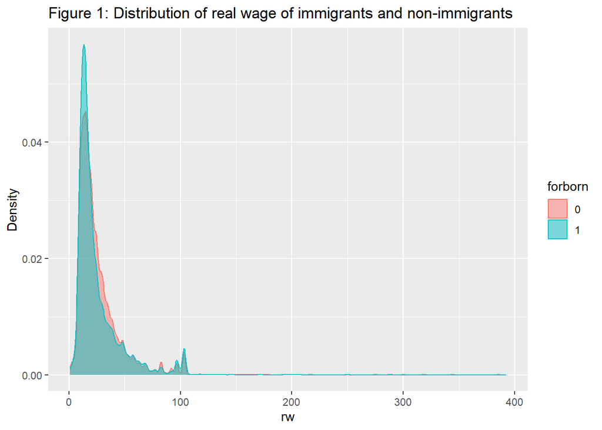

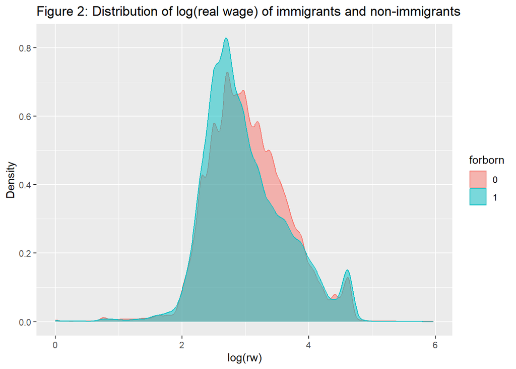

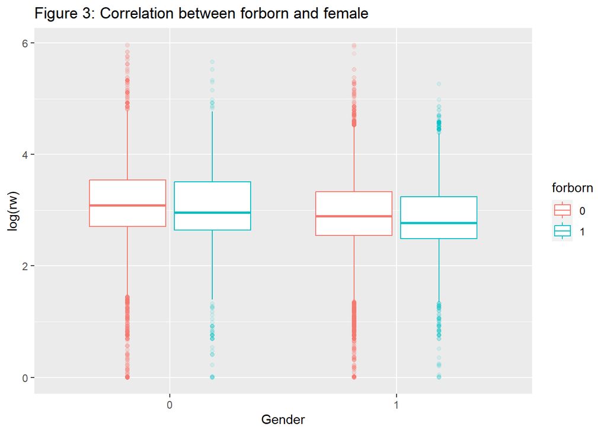

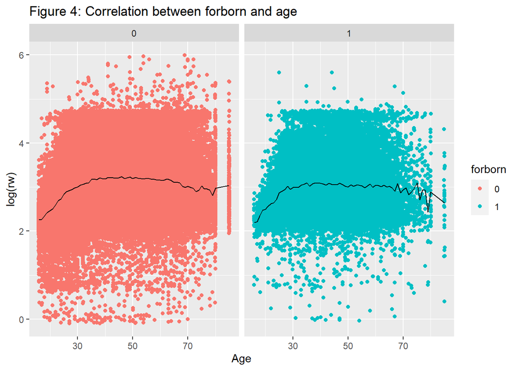

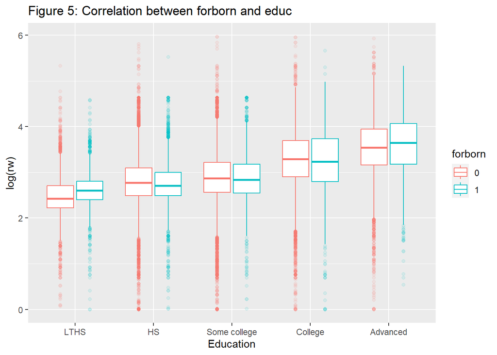

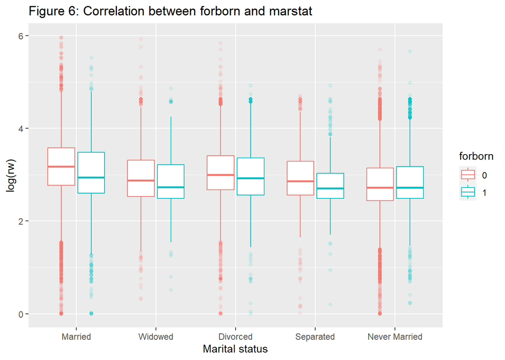

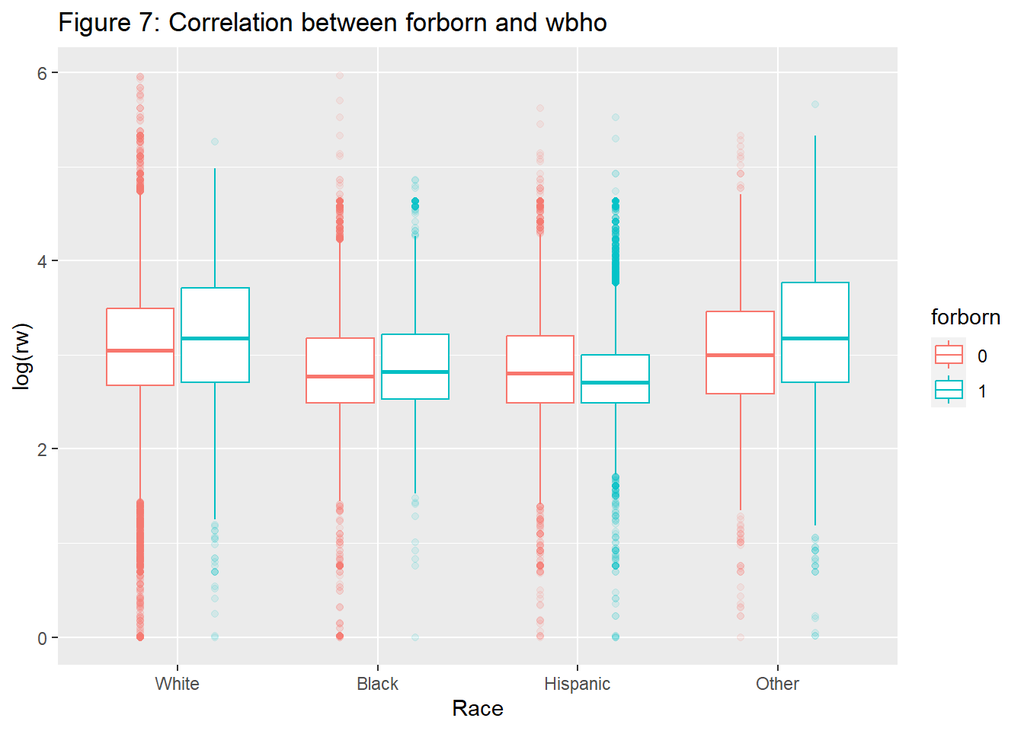

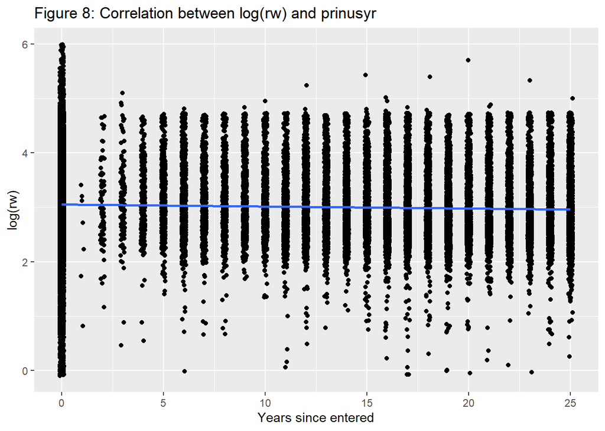

Table 3: Models for rw and log(rw)

|  | (1) | (2) |
| --- | --- | --- |
| (Intercept) | 25.9*** | 3.0*** |
|  | [25.8, 26.1] | [3.0, 3.1] |
|  | s.e. = 0.1 | s.e. = 0.0 |
|  | t = 478.0 | t = 1763.6 |
|  | p = <0.1 | p = <0.1 |
| forborn1 | -0.6** | 0.0** |
|  | [-0.9, -0.4] | [-0.1, 0.0] |
|  | s.e. = 0.1 | s.e. = 0.0 |
|  | t = -4.4 | t = -10.6 |
|  | p = <0.1 | p = <0.1 |
| Num.Obs. | 154279 | 154279 |
| R2 | 0.000 | 0.001 |
| R2 Adj. | 0.000 | 0.001 |
| AIC | 1358130.1 | 1233607.1 |
| BIC | 1358159.9 | 1233636.9 |
| Log.Lik. | -679062.029 | -147325.022 |
| RMSE | 19.74 | 0.63 |

. p < 0.1, * p < 0.05, ** p < 0.01, *** p < 0

Table 4: Models for age

|  | (1) | (2) |
| --- | --- | --- |
| (Intercept) | 2.7*** | 1.5*** |
|  | [2.6, 2.7] | [1.4, 1.5] |
|  | s.e. = 0.0 | s.e. = 0.0 |
|  | t = 546.4 | t = 117.7 |
|  | p = <0.1 | p = <0.1 |
| forborn1 | -0.1** | -0.1** |
|  | [-0.1, -0.1] | [-0.1, -0.1] |
|  | s.e. = 0.0 | s.e. = 0.0 |
|  | t = -13.7 | t = -23.7 |
|  | p = <0.1 | p = <0.1 |
| age | 0.0*** | 0.1*** |
|  | [0.0, 0.0] | [0.1, 0.1] |
|  | s.e. = 0.0 | s.e. = 0.0 |
|  | t = 86.8 | t = 117.4 |
|  | p = <0.1 | p = <0.1 |
| I(age^2) |  | 0.0*** |
|  |  | [0.0, 0.0] |
|  |  | s.e. = 0.0 |
|  |  | t = -103.4 |
|  |  | p = <0.1 |
| Num.Obs. | 154279 | 154279 |
| R2 | 0.047 | 0.109 |
| R2 Adj. | 0.047 | 0.109 |
| AIC | 1226253.9 | 1215912.2 |
| BIC | 1226293.7 | 1215961.9 |
| Log.Lik. | -143647.427 | -138475.584 |
| RMSE | 0.61 | 0.59 |

. p < 0.1, * p < 0.05, ** p < 0.01, *** p < 0

Table 5: Models for the final model

|  | (1) | (2) | (3) | (4) |
| --- | --- | --- | --- | --- |
| (Intercept) | 1.6*** | 1.5*** | 1.8*** | 1.8*** |
|  | [1.5, 1.6] | [1.5, 1.6] | [1.7, 1.8] | [1.7, 1.8] |
|  | s.e. = 0.0 | s.e. = 0.0 | s.e. = 0.0 | s.e. = 0.0 |
|  | t = 125.7 | t = 134.2 | t = 129.8 | t = 129.3 |
|  | p = <0.1 | p = <0.1 | p = <0.1 | p = <0.1 |
| forborn1 | -0.1** | -0.1** | -0.1** | -0.1** |
|  | [-0.1, -0.1] | [-0.1, -0.1] | [-0.1, -0.1] | [-0.1, 0.0] |
|  | s.e. = 0.0 | s.e. = 0.0 | s.e. = 0.0 | s.e. = 0.0 |
|  | t = -25.8 | t = -15.3 | t = -17.1 | t = -12.3 |
|  | p = <0.1 | p = <0.1 | p = <0.1 | p = <0.1 |
| age | 0.1*** | 0.1*** | 0.0*** | 0.0*** |
|  | [0.1, 0.1] | [0.1, 0.1] | [0.0, 0.0] | [0.0, 0.0] |
|  | s.e. = 0.0 | s.e. = 0.0 | s.e. = 0.0 | s.e. = 0.0 |
|  | t = 119.3 | t = 97.6 | t = 78.0 | t = 80.0 |
|  | p = <0.1 | p = <0.1 | p = <0.1 | p = <0.1 |
| I(age^2) | 0.0*** | 0.0*** | 0.0*** | 0.0*** |
|  | [0.0, 0.0] | [0.0, 0.0] | [0.0, 0.0] | [0.0, 0.0] |
|  | s.e. = 0.0 | s.e. = 0.0 | s.e. = 0.0 | s.e. = 0.0 |
|  | t = -105.1 | t = -84.7 | t = -70.7 | t = -72.6 |
|  | p = <0.1 | p = <0.1 | p = <0.1 | p = <0.1 |
| female1 | -0.2*** | -0.2*** | -0.2*** | -0.2*** |
|  | [-0.2, -0.2] | [-0.2, -0.2] | [-0.2, -0.2] | [-0.2, -0.2] |
|  | s.e. = 0.0 | s.e. = 0.0 | s.e. = 0.0 | s.e. = 0.0 |
|  | t = -64.3 | t = -88.2 | t = -86.5 | t = -85.3 |
|  | p = <0.1 | p = <0.1 | p = <0.1 | p = <0.1 |
| educHS |  | 0.2** | 0.2** | 0.2** |
|  |  | [0.2, 0.2] | [0.2, 0.2] | [0.2, 0.2] |
|  |  | s.e. = 0.0 | s.e. = 0.0 | s.e. = 0.0 |
|  |  | t = 31.6 | t = 31.6 | t = 30.3 |
|  |  | p = <0.1 | p = <0.1 | p = <0.1 |

[output cut: 57 more lines]

. p < 0.1, * p < 0.05, ** p < 0.01, *** p < 0

```
## Analysis of Variance Table
##
## Response: log(rw)
##               Df Sum Sq Mean Sq  F value    Pr(>F)
## forborn        1     44    44.4   169.24 < 2.2e-16 ***
## age            1   2840  2839.5 10835.09 < 2.2e-16 ***
## I(age^2)       1   3771  3771.0 14389.41 < 2.2e-16 ***
## female         1   1421  1420.7  5421.15 < 2.2e-16 ***
## educ           4  11991  2997.7 11438.82 < 2.2e-16 ***
## marstat        4    292    73.0   278.50 < 2.2e-16 ***
## wbho           3    250    83.4   318.13 < 2.2e-16 ***
## Residuals 154263  40427     0.3
## ---
## Signif. codes:  0 '***' 0.001 '**' 0.01 '*' 0.05 '.' 0.1 ' ' 1
```

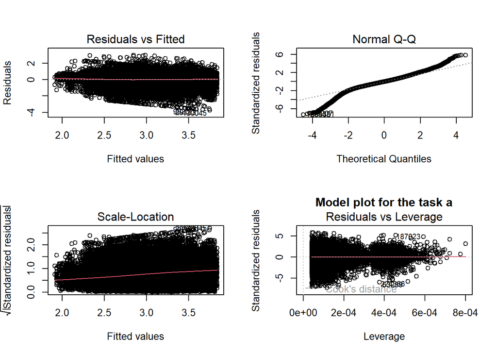

[figure not shown]

```r
# Import libraries
library(foreign)
library(dplyr)
library(ggplot2)
library(car)
library(lmtest)
library(sandwich)
library(fixest)
library(tibble)
library(tidyverse)
library(data.table)
library(modelsummary)
library(kableExtra)

print("Loaded library")
# Read the data as data table
dt = read.dta("cepr_org_2019.dta")
dt = as.data.table(dt)
print("Loaded data")
# Functions
dstat = function(x, ...) {
  c(mean = mean(x, ...),
    sd = sd(x, ...),
    min = min(x, ...),
    max = max(x, ...),
    median = median(x, ...),
    quantile_05 = quantile(x, 0.05, ...),
    quantile_95 = quantile(x, 0.95, ...),
    N = sum(!is.na(x)))
}

coeftest.hc1 = function (x, ...) {
  coeftest(x, vcovHC(x, type = "HC1"), ...)[1:x$rank,]
}

sum_models = function(x, ...) {
  modelsummary(list(x, ...),
               fmt = 1,
               statistic = c("conf.int",
                             "s.e. = {std.error}",
                             "t = {statistic}",
                             "p = {p.value}"),
               conf_level = 0.95,
               stars = c("***" = 0,
                         "**" = 0.01,
                         "*" = 0.05,
                         "." = 0.1))
}

print("Loaded functions")
# To factors
dt$forborn = factor(dt$forborn)
dt$female = factor(dt$female)
dt$married = factor(dt$married)
dt$metro = factor(dt$metro)
dt$union = factor(dt$union)
dt$cert = factor(dt$cert)

print("Convert to factors")
# Answer to question 1
sum_tb = tibble(Mean = double(),
                SD = double(),
                Min = double(),
                Max = double(),
                Median = double(),
                Quantile.05 = double(),
                Quantile.95 = double(),
                N = integer())

# rw
sum_tb[nrow(sum_tb) + 1, ] = t(dstat(dt$rw[dt$forborn==0], na.rm = TRUE))
sum_tb[nrow(sum_tb) + 1, ] = t(dstat(dt$rw[dt$forborn==1], na.rm = TRUE))

# log(rw)
sum_tb[nrow(sum_tb) + 1, ] = t(dstat(log(dt$rw[dt$forborn==0]), na.rm = TRUE))
sum_tb[nrow(sum_tb) + 1, ] = t(dstat(log(dt$rw[dt$forborn==1]), na.rm = TRUE))

# Add "Name" column
sum_tb = sum_tb %>%
  add_column(Name = c("Non-immigrants - rw", "Immigrants - rw", "Non-immigrants -log(rw)", "Immigrants - log(rw)"), .before = "Mean")

# Print table
sum_tb %>%
  kbl(caption = "Table 1: Real wage of non-immigrants and immigrants", digits = 2) %>%
  column_spec(2, color = "cornflowerblue") %>%
  kable_minimal()

# Confident interval for forborn = 1
# t-test ---> Reject the H0
# H0: true difference in means is equal to 0
# H1: true difference in means is not equal to 0
t.test(x = dt$rw[dt$forborn == 1], y = dt$rw[dt$forborn == 0], alternative = "two.sided", conf.level = 0.95, var.equal = TRUE)
# wilcox.test(x = dt$rw[dt$forborn == 1], y = dt$rw[dt$forborn == 0], alternative = "two.sided", conf.level = 0.95)
#should remove
# t-test ---> Accecpt the H0
# H0: x has a smaller mean than y
# H1: x has a larger mean than y
t.test(x = dt$rw[dt$forborn == 1], y = dt$rw[dt$forborn == 0], alternative = "greater", conf.level = 0.95)
# wilcox.test(x = dt$rw[dt$forborn == 1], y = dt$rw[dt$forborn == 0], alternative = "greater", conf.level = 0.95)
# t-test ---> Reject the H0
# H0: x has a larger mean than y
# H1: x has a smaller mean than y
t.test(x = dt$rw[dt$forborn == 1], y = dt$rw[dt$forborn == 0], alternative = "less", conf.level = 0.95)
# wilcox.test(x = dt$rw[dt$forborn == 1], y = dt$rw[dt$forborn == 0], alternative = "less", conf.level = 0.95)
# For the wage gap
model_final = lm(formula = log(rw) ~ forborn + age + I(age^2) + female + educ + marstat + wbho, data = dt)

summary(model_final)

# Set prinusyr = 0 for forborn = 0
dt$prinusyr[dt$forborn==0] = 0
model_final_year = feols(log(rw) ~ forborn + as.factor(prinusyr) + age + I(age^2) + female + educ + wbho + marstat, data = dt, vcov = "HC1")
summary(model_final_year)
dt_by_prins = dt %>% group_by(prinusyr)%>%
        summarise(mean_rw = mean(rw, na.rm = TRUE),
                  mean_age = mean(age, na.rm = TRUE),
                  n_male = sum(!is.na(rw) & female==0),
                  n_female = sum(!is.na(rw) & female==1),
                  n_educ_lths = sum(!is.na(rw) & educ=="LTHS"),
                  n_educ_hs = sum(!is.na(rw) & educ=="HS"),
                  n_educ_sc = sum(!is.na(rw) & educ=="Some college"),
                  n_educ_c = sum(!is.na(rw) & educ=="College"),
                  n_educ_adv = sum(!is.na(rw) & educ=="Advanced"),
                  n = sum(!is.na(rw)))
dt_by_prins %>%
        kbl(caption = "Table 2: Group by the variable prinusyr", digits = 2, col.names = c("prinusyr", "Mean rw", "Mean age", "Male", "Female", "LTHS", "HS", "Some college", "College", "Advanced", "Total")) %>%
        column_spec(2, color = "cornflowerblue") %>%
        kable_minimal()
ggplot(data = dt_by_prins, aes(x = prinusyr)) +
        geom_line(aes(y = mean_rw, color = "red")) +
        geom_line(aes(y = mean_age, color = "green"))

ggplot(data = tail(dt_by_prins, -1), aes(x = prinusyr)) +
        geom_line(aes(y = n_female, color = "red")) +
        geom_line(aes(y = n_male, color = "green")) +
        geom_line(aes(y = n, color = "pink"))

ggplot(data = tail(dt_by_prins, -1), aes(x = prinusyr)) +
        geom_line(aes(y = n_educ_lths, color = "red")) +
        geom_line(aes(y = n_educ_hs, color = "green")) +
        geom_line(aes(y = n_educ_sc, color = "pink")) +
        geom_line(aes(y = n_educ_c, color = "orange")) +
        geom_line(aes(y = n_educ_adv, color = "blue"))
# Distributions of rw and log(rw)
ggplot(dt, aes(x = rw, color = forborn)) +
        geom_density(aes(fill = forborn), alpha = 0.5, na.rm = TRUE) +
        labs(title = "Figure 1: Distribution of real wage of immigrants and non-immigrants",
             x = "rw", y = "Density")

ggplot(dt, aes(x = log(rw), color = forborn)) +
        geom_density(aes(fill = forborn), alpha = 0.5, na.rm = TRUE) +
        labs(title = "Figure 2: Distribution of log(real wage) of immigrants and non-immigrants",
             x = "log(rw)", y = "Density")

ggplot(dt, aes(x = female, y = log(rw), color = forborn)) +
        geom_boxplot(outlier.alpha = 0.1, na.rm = TRUE) +
        labs(title = "Figure 3: Correlation between forborn and female",
             x = "Gender",
             y = "log(rw)")

ggplot(dt, aes(x = age, y = log(rw))) +
        geom_jitter(aes(color = forborn), width = 0.1, height = 0.1, na.rm = TRUE) +
        stat_summary(fun = mean, geom = "line", aes(group = 1), na.rm = TRUE) +
        facet_wrap(~forborn) +
        labs(title = "Figure 4: Correlation between forborn and age",
             x = "Age",
             y = "log(rw)")

ggplot(dt, aes(x = educ, y = log(rw), color = forborn)) +
        geom_boxplot(outlier.alpha = 0.1, na.rm = TRUE) +
        labs(title = "Figure 5: Correlation between forborn and educ",
             x = "Education",
             y = "log(rw)")

ggplot(dt, aes(x = marstat, y = log(rw), color = forborn)) +
        geom_boxplot(outlier.alpha = 0.1, na.rm = TRUE) +
        labs(title = "Figure 6: Correlation between forborn and marstat",
             x = "Marital status",
             y = "log(rw)")

ggplot(dt, aes(x = wbho, y = log(rw), color = forborn)) +
        geom_boxplot(outlier.alpha = 0.1, na.rm = TRUE) +
        labs(title = "Figure 7: Correlation between forborn and wbho",
             x = "Race",
             y = "log(rw)")

ggplot(dt, aes(x = prinusyr, y = log(rw))) +
        geom_jitter(width = 0.1, height = 0.1, na.rm = TRUE) +
        geom_smooth(method = lm, na.rm = TRUE, formula = y ~ x) +
        labs(title = "Figure 8: Correlation between log(rw) and prinusyr",
             x = "Years since entered",
             y = "log(rw)")


model = lm(formula = rw ~ forborn, data = dt)
model_base = lm(formula = log(rw) ~ forborn, data = dt)
model_base_age = lm(formula = log(rw) ~ forborn + age, data = dt)
model_base_age_poly = lm(formula = log(rw) ~ forborn + age + I(age^2), data = dt)
model_base_female = lm(formula = log(rw) ~ forborn + female, data = dt)
model_base_educ = lm(formula = log(rw) ~ forborn + educ, data = dt)
model_base_wbho = lm(formula = log(rw) ~ forborn + wbho, data = dt)
model_base_marstat = lm(formula = log(rw) ~ forborn + marstat, data = dt)
model_base_metro = lm(formula = log(rw) ~ forborn + metro, data = dt)
model_age_female = lm(formula = log(rw) ~ forborn + age + female, data = dt)
model_age_poly_female = lm(formula = log(rw) ~ forborn + age + I(age^2) + female, data = dt)
model_age_poly_female_educ = lm(formula = log(rw) ~ forborn + age + I(age^2) + female + educ, data = dt)
model_age_poly_female_educ_marstat = lm(formula = log(rw) ~ forborn + age + I(age^2) + female + educ + marstat, data = dt)
model_age_poly_female_educ_marstat_wbho = lm(formula = log(rw) ~ forborn + age + I(age^2) + female + educ + marstat + wbho, data = dt)


modelsummary(list(model, model_base),
             title = "Table 3: Models for rw and log(rw)",
             fmt = 1,
             statistic = c("conf.int",
                           "s.e. = {std.error}",
                           "t = {statistic}",
                           "p = {p.value}"),
             conf_level = 0.95,
             stars = c("***" = 0,
                       "**" = 0.01,
                       "*" = 0.05,
                       "." = 0.1),
             output = "kableExtra")

modelsummary(list(model_base_age, model_base_age_poly),
             title = "Table 4: Models for age",
             fmt = 1,
             statistic = c("conf.int",
                           "s.e. = {std.error}",
                           "t = {statistic}",
                           "p = {p.value}"),
             conf_level = 0.95,
             stars = c("***" = 0,
                       "**" = 0.01,
                       "*" = 0.05,
                       "." = 0.1),
             output = "kableExtra")

modelsummary(list(model_age_poly_female, model_age_poly_female_educ, model_age_poly_female_educ_marstat, model_age_poly_female_educ_marstat_wbho),
             title = "Table 5: Models for the final model",
             fmt = 1,
             statistic = c("conf.int",
                           "s.e. = {std.error}",
                           "t = {statistic}",
                           "p = {p.value}"),
             conf_level = 0.95,
             stars = c("***" = 0,
                       "**" = 0.01,
                       "*" = 0.05,
                       "." = 0.1),
             output = "kableExtra")
anova(model_final)
# anova(model_final_year)
par(mfrow=c(2, 2))
plot(model_final)
title(main = "Model plot for the task a")
coefplot(model_final_year)
title(main = "Coefficient plot for the task b")
par(mfrow=c(1, 1))
```